# SASPs and UV

Heath Blackmon

2023-11-10

## Background

In this project we are attempting to identify whether there are certain sites in the genome that are protected from UV damage by SASPs. The Blackmon lab received 4 sequencing datasets named: S97, S98, S99, and S100. Our expectation is that two of these files should show a pattern where some sites are protected from UV damage and two should show a pattern consistent with UV light having caused the formation of pyrimidine dimers. This occurs when two adjacent pyrimidine bases (thymine or cytosine) in a DNA strand bond together. This should cause errors and failure of some sequencing reads when they reach a dimer. We are attempting to detect and classify these sequencing runs and then once classified we can identify the sites in the genome that show the pattern expected with premature stops in our reads.

## Coverage Analysis

Our first approach was simply to look at read depth along the genome. We reasoned that in the UV treated datasets we should see dips in the read depth at sites that were frequently mutated to dimers. Briefly, reads were mapped to a reference genome, filtering out any reads with a quality score below 20. The reference genome for C. difficile R20291 was sourced from NCBI with the GenBank reference entry: FN545816.1. I proceeded with the mapping of filtered reads to the reference genome utilizing minimap 2.1 set to the configuration of the short read. The resulting alignments were compiled into a SAM file, converted to a BAM file, and then sorted (all with Samtools). The Samtools depth command was executed to obtain a tab-delimited text file detailing base pair positions and corresponding coverage.

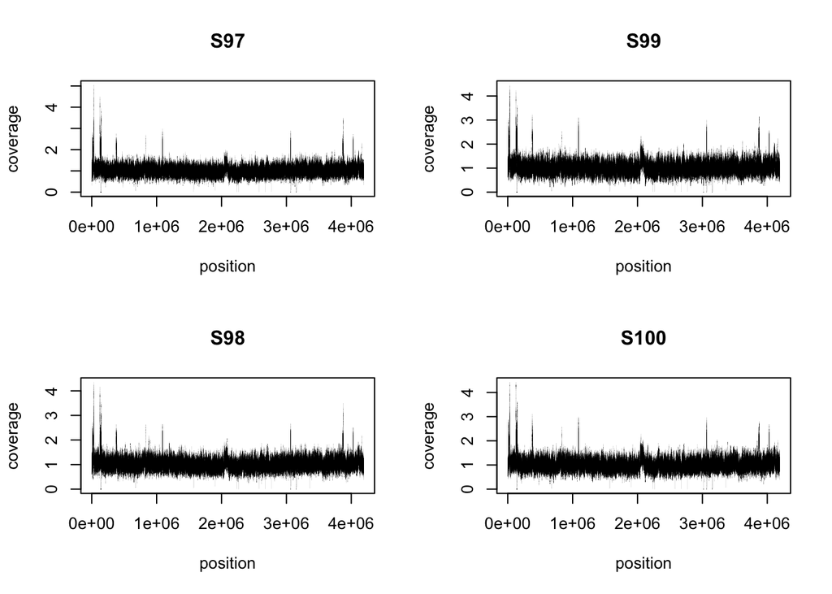

```r
# read in the mapping results
dat <- read.table("../results/coverage/S97_modcov.txt")
dat[,3]<-read.table("../results/coverage/S98_modcov.txt")[,2]
dat[,4]<-read.table("../results/coverage/S99_modcov.txt")[,2]
dat[,5]<-read.table("../results/coverage/S100_modcov.txt")[,2]
colnames(dat) <- c("pos","S97","S98","S99","S100")

# now lets normalize across datasets
dat[,2] <- dat[,2]/mean(dat[,2])
dat[,3] <- dat[,3]/mean(dat[,3])
dat[,4] <- dat[,4]/mean(dat[,4])
dat[,5] <- dat[,5]/mean(dat[,5])

# plot results
par(mfcol=c(2,2))
plot(dat$S97~dat$pos, type="l",lwd=.05, ylab="coverage", xlab="position",main="S97")
plot(dat$S98~dat$pos, type="l",lwd=.05, ylab="coverage", xlab="position",main="S98")
plot(dat$S99~dat$pos, type="l",lwd=.05, ylab="coverage", xlab="position",main="S99")
plot(dat$S100~dat$pos, type="l",lwd=.05, ylab="coverage", xlab="position",main="S100")
```

So in looking at these plots we see that there are not shocking and clear differences among data sets that are discernible from simple visual inspection at this scale. In fact, the plots are so similar that we went back and triple checked that we hadn’t accidentally used the same file multiple times. We did not, instead this similarity is likely driven by the sequence characteristics of the genome and a bias that is present in Illumina sequencing. Specifically the GC content of the genome (GC rich regions are more difficult to sequence).

## Read length distributions

Our next step was to compare the distribution of read lengths across data sets. If two of these samples have an excess of pyrimidine dimers, it stands to reason that they would have a smaller mean read length due to prematurely stopped sequencing reads

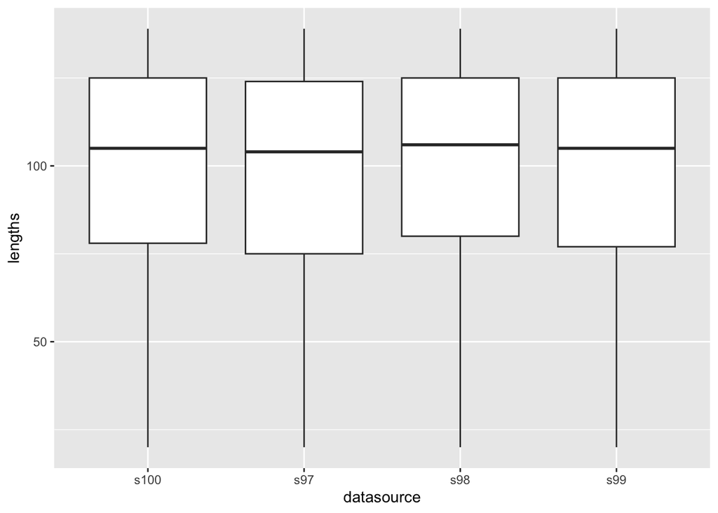

```r
library(ggplot2)
dat97 <- read.table("../results/read_distrib/read_lengths97.txt")
dat98 <- read.table("../results/read_distrib/read_lengths98.txt")
dat99 <- read.table("../results/read_distrib/read_lengths99.txt")
dat100 <- read.table("../results/read_distrib/read_lengths100.txt")
dat <- data.frame(c(dat97[,1], dat98[,1], dat99[,1], dat100[,1]))
dat$set <- c(rep("s97",nrow(dat97)),rep("s98",nrow(dat98)),
             rep("s99",nrow(dat99)),rep("s100",nrow(dat100)))
colnames(dat) <- c("lengths", "datasource")
# if we plot all the data you cant see much at all becuase the overwhelming
# majority of reads are full length to deal with this I slimmed the data
# down to reads less than 140 bp.
dat2 <- dat[dat$lengths < 140,]
ggplot(data=dat2, aes(x=datasource, y=lengths)) +
  geom_boxplot()
```

So, visual inspection just won’t cut it; instead, let’s fit an anova and GLM and see what data sets if any are significantly different in mean read length.

```r
fit <- glm(dat$lengths ~ dat$datasource)
summary(fit)
```

```
##
## Call:
## glm(formula = dat$lengths ~ dat$datasource)
##
## Coefficients:
##                     Estimate Std. Error   t value Pr(>|t|)
## (Intercept)       147.838405   0.007197 20540.957  < 2e-16 ***
## dat$datasources97   0.267879   0.010157    26.375  < 2e-16 ***
## dat$datasources98  -0.069498   0.009954    -6.982 2.92e-12 ***
## dat$datasources99  -0.117525   0.010145   -11.584  < 2e-16 ***
## ---
## Signif. codes:  0 '***' 0.001 '**' 0.01 '*' 0.05 '.' 0.1 ' ' 1
##
## (Dispersion parameter for gaussian family taken to be 168.9882)
##
##     Null deviance: 2270082408  on 13431641  degrees of freedom
## Residual deviance: 2269787829  on 13431638  degrees of freedom
## AIC: 107019377
##
## Number of Fisher Scoring iterations: 2
```

```r
summary(aov(fit))
```

```
##                      Df    Sum Sq Mean Sq F value Pr(>F)
## dat$datasource        3 2.946e+05   98193   581.1 <2e-16 ***
## Residuals      13431638 2.270e+09     169
## ---
## Signif. codes:  0 '***' 0.001 '**' 0.01 '*' 0.05 '.' 0.1 ' ' 1
```

```r
TukeyHSD(aov(fit))
```

```
##   Tukey multiple comparisons of means
##     95% family-wise confidence level
##
## Fit: aov(formula = fit)
##
## $`dat$datasource`
##                 diff         lwr         upr   p adj
## s97-s100  0.26787946  0.24178673  0.29397218 0.0e+00
## s98-s100 -0.06949837 -0.09507128 -0.04392546 0.0e+00
## s99-s100 -0.11752524 -0.14358888 -0.09146159 0.0e+00
## s98-s97  -0.33737782 -0.36289344 -0.31186221 0.0e+00
## s99-s97  -0.38540469 -0.41141212 -0.35939726 0.0e+00
## s99-s98  -0.04802687 -0.07351274 -0.02254100 7.7e-06
```

As is often the case these differences are really small but the sample sizes are so large the result is significant. In fact, all datasets have significantly different means. But, these differences are on the order of less than a bp. In fact, the entire range of from the mean of the highest group 148.11 to the mean of the lowest group 147.72 is only 0.4 bp. To us this suggests that few reads per library actually contain any deviation from the expectation of around 150 bp.

## Read length distribution

Even if the means are very similar, it might be that the short reads are concentrated in certain portions of the genome. To assess this we decided to plot the length of each read against its median position in the genome. This should reveal dips in read length if their are regions that are consistently producing short reads as we might expect with this experiment.

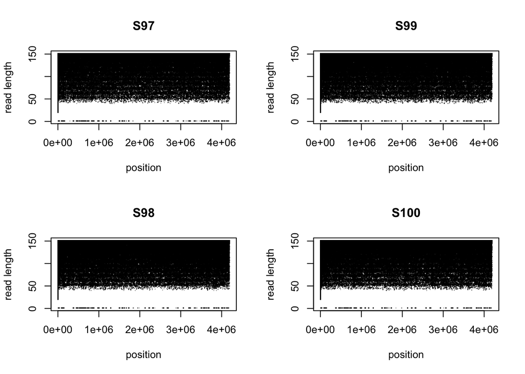

```r
dat97 <- read.table("../results/length_by_position_plot/97_sorted.txt")
dat98 <- read.table("../results/length_by_position_plot/98_sorted.txt")
dat99 <- read.table("../results/length_by_position_plot/99_sorted.txt")
dat100 <- read.table("../results/length_by_position_plot/100_sorted.txt")
par(mfcol=c(2,2))
plot(x=dat97[,1], y=dat97[,2], cex=.2, pch=16, col=rgb(0,0,0,.5),
     ylab="read length",xlab="position", main="S97")
plot(x=dat98[,1], y=dat98[,2], cex=.2, pch=16, col=rgb(0,0,0,.5),
     ylab="read length",xlab="position", main="S98")
plot(x=dat99[,1], y=dat99[,2], cex=.2, pch=16, col=rgb(0,0,0,.5),
     ylab="read length",xlab="position", main="S99")
plot(x=dat100[,1], y=dat100[,2], cex=.2, pch=16, col=rgb(0,0,0,.5),
     ylab="read length",xlab="position", main="S100")
```

What I was hoping for and don’t see here is obvious areas where most of two strains are exhibiting lower read length. In fact, similar to the analysis of read depth here again the similarities among plots is much more striking than any variation among them. As one more check of read length distributions, below I calculate the mean read length for all reads that map to 2000 base pair windows along the genome. The data is dominated by reads that are full or near full length (82-83%). So I further cleaned the data by only retaining windows with a mean less than 140. This will remove some of the noise in the data and only retain those reads that are shorter than we might expect.

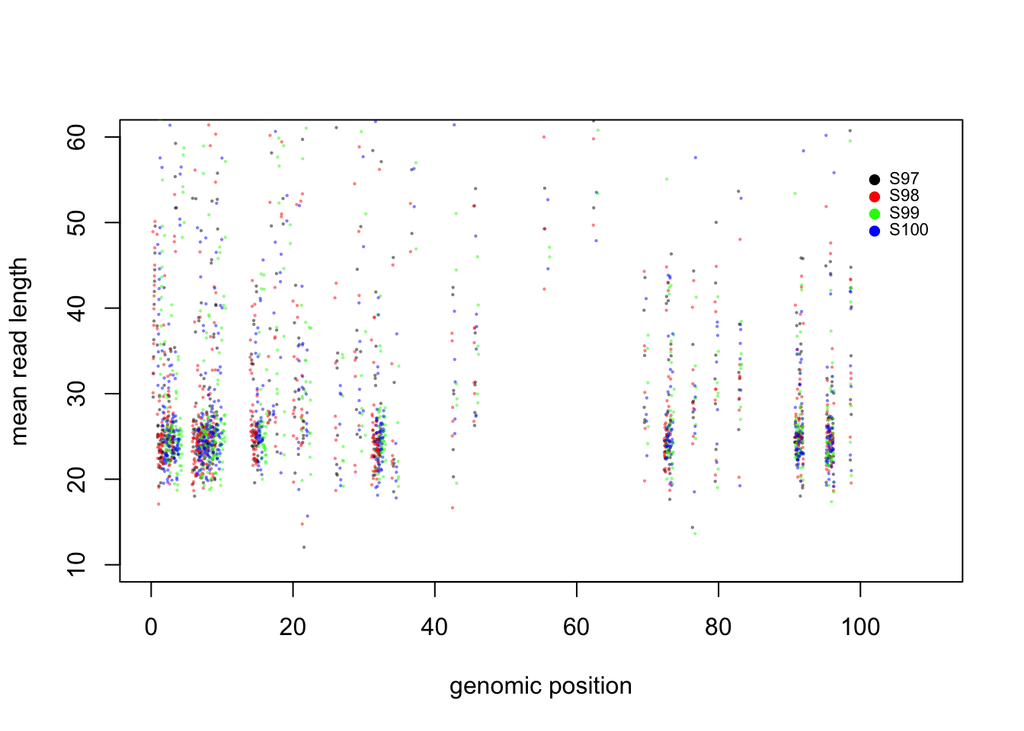

```r
s97 <- SlidingWindow(mean, dat97[,2], 2000, 1000)
s98 <- SlidingWindow(mean, dat98[,2], 2000, 1000)
s99 <- SlidingWindow(mean, dat99[,2], 2000, 1000)
s100 <- SlidingWindow(mean, dat100[,2], 2000, 1000)
plot(y=s97, x=seq(from=0, to=100, length.out= 3777),pch=16,
     cex=.3,col=rgb(0,0,0,.5),ylim=c(10,60), xlim=c(0,110),
     ylab = "mean read length", xlab="genomic position")
points(y=s98, x=seq(from=0, to=100, length.out= 4080), pch=16, cex=.3,col=rgb(1,0,0,.5))
points(y=s99, x=seq(from=0, to=100, length.out= 3802), pch=16, cex=.3,col=rgb(0,1,0,.5))
points(y=s100, x=seq(from=0, to=100, length.out= 3738), pch=16, cex=.3,col=rgb(0,0,1,.5))
points(x=102,y=55,pch=16)
points(x=102,y=53,pch=16,col="red")
points(x=102,y=51,pch=16,col="green")
points(x=102,y=49,pch=16,col="blue")
text(x=rep(102,4),y=c(55,53,51,49),c("S97","S98","S99","S100"),cex=.7,pos=4)
```

As with other analyses, we see a pattern where all four samples have dips in read length at the same locations in the genome. I want to confirm that these regions are those we would expect to be hard to sequence so Megan’s next step is to plot these read lengths as function of GC content. My guess is that these regions will be GC rich.